# PRA1 - Selección y preparación de un juego de datos

Minería de datos

Abril 2025

Autor: Miriam Gimeno Fernández

## Índice de contenidos

1. Introducción
2. Paso 1: Establecer un objetivo analítico
3. Paso 2: Selección del Juego de Datos
4. Paso 3: Análisis Exploratorio
5. Paso 4: Limpieza y Acondicionado de Datos
6. Paso 5: Métodos de Discretización
7. Paso 6: Análisis PCA

## **Introducción**

[ inicio del documento ]

En colaboración con el Ministerio de Sanidad de España y aprovechando nuestra experiencia en minería de datos y análisis de hábitos poblacionales, hemos impulsado una iniciativa conjunta con el objetivo de comprender mejor los factores asociados al desarrollo de la obesidad en la población española y mejorar las estrategias de prevención a través de técnicas avanzadas de analítica de datos. Esta colaboración busca aprovechar el potencial del análisis estadístico y el aprendizaje automático para abordar esta problemática con un enfoque innovador, orientado tanto a la prevención como a la acción personalizada.

#### **Nuestra Propuesta**

Como empresa privada colaborativa, DataHealth Analytics trabaja en estrecha cooperación con el Ministerio de Sanidad para desarrollar modelos predictivos basados en técnicas de clasificación supervisada, con el fin de predecir el nivel de obesidad de una persona a partir de sus características personales, hábitos alimenticios y nivel de actividad física. Esta colaboración busca dotar al Ministerio de herramientas analíticas avanzadas que respalden la toma de decisiones basada en datos, especialmente en el diseño de campañas de prevención más efectivas y focalizadas.

Además, ofrecemos estos estudios y modelos a clínicas privadas y hospitales, tanto públicos como privados, permitiéndoles aplicar nuestras herramientas de clasificación para anticiparse al riesgo de obesidad en sus pacientes, personalizar tratamientos y mejorar la precisión diagnóstica. Esto facilitará una segmentación precisa de la población según su nivel de riesgo y patrones de comportamiento, optimizando la intervención preventiva y terapéutica.

#### **Objetivos del Estudio:**

1. Construir modelos de clasificación supervisada capaces de predecir con precisión el nivel de obesidad de un individuo a partir de variables relacionadas con estilo de vida, características demográficas y hábitos de consumo.
2. Identificar los factores de riesgo más relevantes asociados a cada categoría de obesidad, utilizando algoritmos interpretables como árboles de decisión y modelos más complejos como Random Forest o SVM.
3. Aplicar técnicas de clasificación no supervisada, como K-means, para segmentar a la población en perfiles homogéneos según patrones de comportamiento, facilitando la implementación de estrategias personalizadas tanto a nivel institucional como clínico.

#### **Impacto y Aplicaciones**

El análisis permitirá al Ministerio de Sanidad tomar decisiones basadas en datos para diseñar campañas de concienciación personalizadas y considerar el desarrollo de herramientas digitales de prevención, como aplicaciones móviles, para mejorar los hábitos de salud en la población.

Por otro lado, las clínicas y hospitales privados podrán utilizar nuestros modelos predictivos para diseñar tratamientos más personalizados, basados en el análisis de los datos específicos de sus pacientes, mejorando los resultados clínicos y optimizando el uso de los recursos médicos.

#### **Ventajas de nuestra colaboración público-privada**

- Ministerio de Sanidad: Herramientas basadas en datos para crear políticas de salud pública más efectivas.
- Clínicas y hospitales privados: Soluciones personalizadas para mejorar los tratamientos de los pacientes, incrementar la eficiencia y reducir costos.

A través de esta colaboración, buscamos dar un paso más allá en la lucha contra la obesidad, utilizando los datos como herramienta para mejorar los resultados de salud pública y privada en España.

## **Paso 1: Establecer un objetivo analítico**

[ inicio del documento ]

El primer paso en todo proyecto de analítica de datos consiste en definir con claridad el objetivo analítico. En otras palabras, formular la pregunta clave que deseamos responder utilizando datos. Como es bien sabido, una buena respuesta comienza con una buena pregunta.

En este estudio, nos planteamos el siguiente interrogante principal:

> **¿Es posible predecir el nivel de obesidad de una persona a partir de sus características personales, conductuales y de estilo de vida?**

Además, se pretende responder a cuestiones complementarias como:

> - ¿Qué hábitos de vida están más asociados con la obesidad?
> - ¿Existen perfiles de comportamiento similares que se repitan en personas con un mismo grado de obesidad?

**Objetivo principal:** Construir un modelo de clasificación supervisada que permita predecir el nivel de obesidad de una persona a partir de sus características personales, hábitos alimenticios y nivel de actividad física. Este modelo no solo permitirá identificar el grado actual de obesidad, sino también estimar la predisposición futura de un individuo a desarrollar obesidad, lo cual resulta clave para diseñar estrategias de prevención anticipada y tratamientos personalizados.

#### **Tipología de la pregunta analítica**

Este estudio contempla dos tipos de tareas de analítica de datos:

- Segmentación no supervisada: se aplicarán técnicas como K-means para identificar grupos homogéneos dentro de la población en función de sus hábitos y características.
- Clasificación supervisada: se entrenarán modelos para predecir la variable categórica NObeyesdad (nivel de obesidad), utilizando algoritmos de aprendizaje supervisado como árboles de decisión, Random Forest o SVM.

#### **Medidas para evaluar el cumplimiento del objetivo**

Para las tareas de clasificación, podríamos utilizar las siguientes métricas:

- Precisión (accuracy) global del modelo.
- Métricas por clase: precisión, recall y F1-score para cada nivel de obesidad.
- Matriz de confusión, para visualizar el rendimiento en cada categoría.

En el caso de la segmentación, se evaluará la coherencia de los grupos con métricas como el coeficiente de Silhouette, que mide la cohesión interna de los clusters.

Se considera un resultado aceptable alcanzar al menos un 85 % de precisión en los modelos predictivos, y obtener una segmentación que permita interpretar claramente los perfiles de cada grupo.

#### **Comprensión del contexto y posibles aplicaciones**

La obesidad es uno de los principales retos de salud pública en España y en todo el mundo. Está asociada a un incremento de enfermedades crónicas (diabetes, hipertensión, enfermedades cardiovasculares), lo que conlleva un aumento del gasto sanitario y un descenso de la calidad de vida.

Por tanto, este estudio tiene aplicaciones directas en:

- El diseño de campañas de prevención más efectivas, dirigidas a perfiles concretos.
- El desarrollo de políticas públicas basadas en datos empíricos.
- La creación de sistemas de recomendación o apps móviles para autocontrol del peso, hábitos y salud.

#### **Viabilidad de la respuesta con los datos disponibles**

El conjunto de datos seleccionado contiene información de más de 2000 individuos, incluyendo variables como edad, peso, altura, alimentación, ejercicio, consumo de sustancias y transporte habitual, así como el nivel de obesidad. Esta información es suficiente y relevante para construir tanto modelos predictivos como análisis exploratorios y de segmentación.

## **Paso 2: Selección y justificación del conjunto de datos**

[ inicio del documento ]

Para poder abordar los objetivos analíticos propuestos, es fundamental contar con un conjunto de datos que contenga información relevante, actual y estructurada de forma adecuada para aplicar técnicas tanto supervisadas como no supervisadas. En este estudio, se ha seleccionado un dataset público relacionado con hábitos de vida y niveles de obesidad en personas jóvenes y adultas, el cual se puedo obtener del sigueitne enlace (*https://www.kaggle.com/datasets/adeniranstephen/obesity-prediction-dataset*).

#### **Descripción del conjunto de datos**

El dataset contiene información de aproximadamente 2100 personas, incluyendo variables que recogen tanto datos objetivos (edad, peso, altura) como aspectos subjetivos relacionados con el estilo de vida y la alimentación. Las variables incluidas son las siguientes:

**Datos demográficos y físicos:**

- Gender: Género (Masculino/Femenino)
- Age: Edad (en años)
- Height: Altura (en metros)
- Weight: Peso (en kilogramos)

**Hábitos alimentarios y estilo de vida:**

**Variable objetivo:**

- NObeyesdad: Nivel de obesidad (categoría con 7 clases, desde "Insufficient Weight" hasta "Obesity Type III")

### Justificación de la elección del dataset###

Este conjunto de datos ha sido seleccionado por los siguientes motivos:

1. **Relevancia temática:**
- El dataset está directamente alineado con el objetivo del estudio, ya que proporciona información clave sobre los hábitos de vida y su relación con el nivel de obesidad.
2. **Adecuación para tareas supervisadas:**
- La variable NObeyesdad permite entrenar modelos de clasificación multiclase, ya que incluye 7 niveles distintos, lo que enriquece el análisis y abre la puerta a modelos más específicos y matizados.
3. **Potencial para técnicas no supervisadas:**
- Las múltiples variables relacionadas con estilo de vida permiten aplicar técnicas de clustering (como K-means o DBSCAN) para descubrir patrones ocultos o perfiles poblacionales con características similares.
4. **Calidad y completitud de los datos:**
- El dataset no contiene valores faltantes y presenta una estructura limpia, lo cual facilita el análisis inicial y reduce la carga de preprocesamiento.
- Contiene mas de 2100 observaciones, variables númericas, categoricas y binarias.
5. **Disponibilidad y uso ético:**
- Se trata de un dataset de uso público, lo que garantiza que se puede utilizar con fines académicos y de investigación sin vulnerar derechos de privacidad ni protección de datos.

### Potencial analítico###

Gracias a la diversidad y calidad de sus variables, este dataset no solo permite la construcción de modelos predictivos robustos, sino también el análisis exploratorio de datos (EDA), la visualización de correlaciones, la reducción de dimensionalidad mediante PCA o SVD, y la segmentación de perfiles para fines de prevención personalizada.

## **Paso 3: Análisis Exporatorio**

[ inicio del documento ]

Vamos a comenzar analizando nuestro conjunto de datos, para ello, primero cargaremos nuestros datos desde la pagina Kaggle y guardaremos nuestro documento como csv

```python
import kagglehub
import pandas as pd
import os


# Download latest version
path = kagglehub.dataset_download("adeniranstephen/obesity-prediction-dataset")

# Cargamos el archivo
file_path = os.path.join(path,"ObesityDataSet_raw_and_data_sinthetic.csv")
# Guardamos el archivo cargado
df2 = pd.read_csv(file_path)
# Mostramos los primeros registros
print(df2.head())
```

```
   Gender  Age  Height  Weight family_history_with_overweight FAVC  FCVC  NCP  \
0  Female   21    1.62    64.0                            yes   no   2.0  3.0
1  Female   21    1.52    56.0                            yes   no   3.0  3.0
2    Male   23    1.80    77.0                            yes   no   2.0  3.0
3    Male   27    1.80    87.0                             no   no   3.0  3.0
4    Male   22    1.78    89.8                             no   no   2.0  1.0

        CAEC SMOKE  CH2O  SCC  FAF  TUE        CALC                 MTRANS  \
0  Sometimes    no   2.0   no  0.0  1.0          no  Public_Transportation
1  Sometimes   yes   3.0  yes  3.0  0.0   Sometimes  Public_Transportation
2  Sometimes    no   2.0   no  2.0  1.0  Frequently  Public_Transportation
3  Sometimes    no   2.0   no  2.0  0.0  Frequently                Walking
4  Sometimes    no   2.0   no  0.0  0.0   Sometimes  Public_Transportation

            NObeyesdad
0        Normal_Weight
1        Normal_Weight
2        Normal_Weight
3   Overweight_Level_I
4  Overweight_Level_II
```

A continuacion para entender de forma rápida las caracteristicas principales del cojunto de datos y detectar posibles problemas, patrones y conocer la distribución de los datos, vamos a utilizar la función `describe()` que nos permite obtener un resumen estadístico.

```python
# Obtener un resumen estadístico de las columnas numéricas
summary = df2.describe()

# Mostrar el resumen
print(summary)
```

```
               Age       Height       Weight         FCVC          NCP  \
count  2111.000000  2111.000000  2111.000000  2111.000000  2111.000000
mean     24.315964     1.701620    86.586035     2.418986     2.685651
std       6.357078     0.093368    26.191163     0.533996     0.778079
min      14.000000     1.450000    39.000000     1.000000     1.000000
25%      20.000000     1.630000    65.470000     2.000000     2.660000
50%      23.000000     1.700000    83.000000     2.390000     3.000000
75%      26.000000     1.770000   107.430000     3.000000     3.000000
max      61.000000     1.980000   173.000000     3.000000     4.000000

              CH2O          FAF          TUE
count  2111.000000  2111.000000  2111.000000
mean      2.008053     1.010313     0.657861
std       0.612950     0.850613     0.608926
min       1.000000     0.000000     0.000000
25%       1.585000     0.125000     0.000000
50%       2.000000     1.000000     0.625000
75%       2.480000     1.670000     1.000000
max       3.000000     3.000000     2.000000
```

Con el resumen de los datos obtenido, podemos hacer las siguientes observaciones:

**1. Análisis general del conjunto de datos:**

- Hay 2111 observaciones en cada variable, lo que indica que no hay valores faltantes en ninguna de las columnas analizadas.
- Cada variable tiene valores que cubren diferentes rangos, lo cual puede ser útil para identificar patrones o relaciones entre ellas.

**2. Observaciones específicas por variables:**

**Habitos alimenticios y estilo de vida:**

- FCVC (Frecuencia de consumo de verduras):
  - Más del 50% de los individuos consumen verduras al menos con una frecuencia moderada (percentil 50=2.39, percentil 75=3)
- NCP (Número de comidas principales al día):
  - La mayoría de las personas tienden a consumir entre 2 y 3 comidas principales al día (percentil 75).
- CH2O (Consumo de agua en litros diarios):
  - Se observa un promedio de 2l y la distribución está agrupada cerca de este promodeio.

**Actividad física:**

- FAF (Frecuencia de actividad física semanal):
  - El promedio esta en el 1, lo cual sugiere niveles bajos de actividad física y un porcentaje significativo de individuos no realizan actividad físcia reguarlamente (percentil 25 = 0.1)
- TUE (Tiempo usando dispositivos electrónicos):
  - Más de la mitad de los individuos usan dispositivos al menos esporádicamente (percentil 50 = 0.625).

Para continuar con nuestro análisis, vamos a comprobar que no tengamos datos faltantes o nulos

```python
# Verificar si hay valores nulos en el DataFrame
print(df2.isnull().sum())

print("¿Hay valores nulos en el DataFrame?", df2.isnull().values.any())
```

```
Gender                            0
Age                               0
Height                            0
Weight                            0
family_history_with_overweight    0
FAVC                              0
FCVC                              0
NCP                               0
CAEC                              0
SMOKE                             0
CH2O                              0
SCC                               0
FAF                               0
TUE                               0
CALC                              0
MTRANS                            0
NObeyesdad                        0
dtype: int64
¿Hay valores nulos en el DataFrame? False
```

Vamos a continuar creando histogramas para continuar analizando la distribución de las variables.

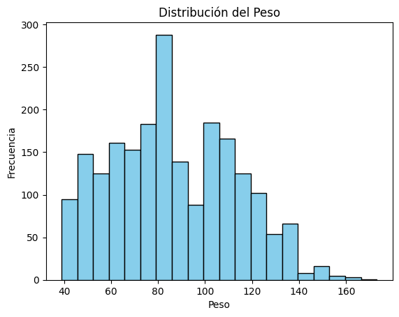

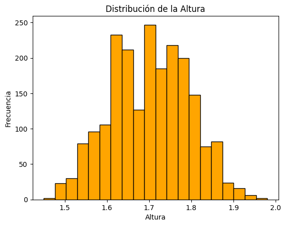

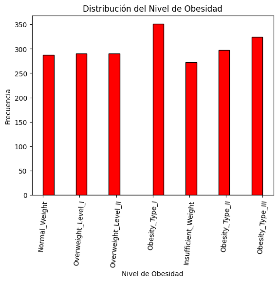

```python
import matplotlib.pyplot as plt

# Gráfico de barras para Weight
plt.hist(df2['Weight'], bins=20, color='skyblue', edgecolor='black')
plt.title("Distribución del Peso")
plt.xlabel("Peso")
plt.ylabel("Frecuencia")
plt.show()

# Gráfico de barras para Height
plt.hist(df2['Height'], bins=20, color='orange', edgecolor='black')
plt.title("Distribución de la Altura")
plt.xlabel("Altura")
plt.ylabel("Frecuencia")
plt.show()

# Gráfico de barras para Nivel de obsedidad
plt.hist(df2['NObeyesdad'], bins=20, color='red', edgecolor='black')
plt.title("Distribución del Nivel de Obesidad")
plt.xlabel("Nivel de Obesidad")
plt.ylabel("Frecuencia")
plt.xticks(rotation=85)
plt.show()
```

En los datos recogidos la frecuancia mas alta para el peso está entorno a 80kg, mientras que la altura está mas repartida.

Un dato que nos llama la atención es la frecuencia para niveles de obesidad de tipo I la cual destaca del resto, siguiendole obesidad de tipo III, lo que sugiere una concentración significativa de pacientes con obesidad en distintos grados, mientras que categorias como Normal_Weight (Peso normal) tienen menor representación. Esto podría indicar que la obesidad es un problema importante en esta población

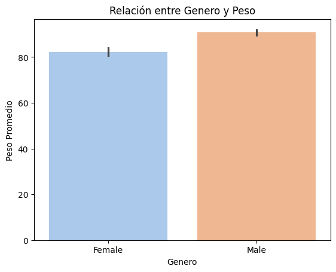

```python
import seaborn as sns

sns.barplot(x='Gender', y='Weight', hue='Gender', data=df2, palette='pastel')
plt.title("Relación entre Genero y Peso")
plt.xlabel("Genero")
plt.ylabel("Peso Promedio")
plt.show()
```

En este grafico vemos una perpectiva interesante sobre cómo se correlaciona el género con el peso promedio. La comparación visual, muestra que los hombres tienen un peso promedio ligeramente superior al de las mujeres, represntado por la barra naranja para "Male" (Hombre) y azul "Famale" (Mujer).

Esta distribución puede proporcionar valiosos insights, especialmente al analizar diferencias en métricas de salud, patrones alimenticios o hábitos de estilo de vida entre géneros.

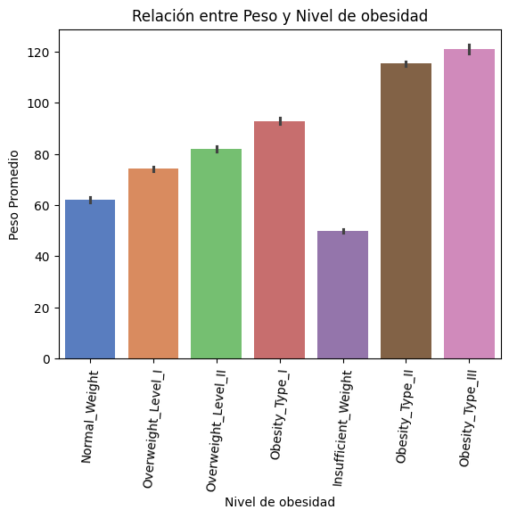

```python
sns.barplot(x='NObeyesdad', y='Weight', hue='NObeyesdad', data=df2, palette='muted', dodge=False, legend=False)
plt.title("Relación entre Peso y Nivel de obesidad")
plt.xlabel("Nivel de obesidad")
plt.ylabel("Peso Promedio")
plt.xticks(rotation=85)  # Girar etiquetas para que sean más legibles
plt.show()
```

En este grafico podemos observar como estan clasificados los niveles de obesidad segun peso.

A continuacion haremos una grafica para visualizar la relacion del peso con la frecuencia de comida entre comidas.

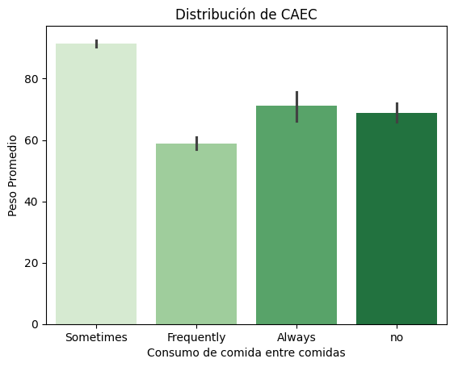

```python
# Gráfico de CALC
sns.barplot(x='CAEC', y='Weight', hue='CAEC', data=df2, palette='Greens', legend=False)
plt.title("Distribución de CAEC")
plt.xlabel("Consumo de comida entre comidas")
plt.ylabel("Peso Promedio")
plt.show()
```

Se puede obserbas que los individuos en los que algunas veces realizan las comidas entre comidas, tienen un peso promedio mas elevado.

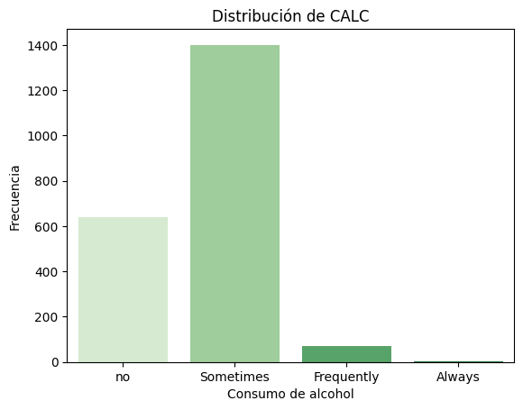

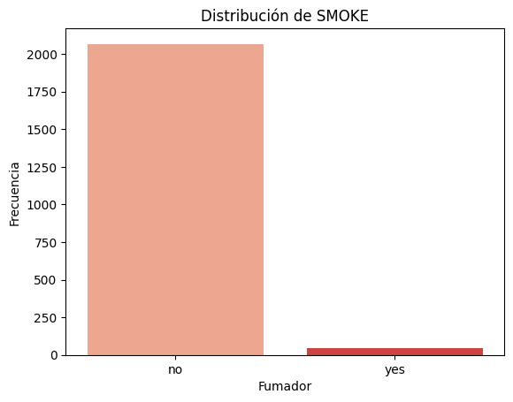

```python
# Gráfico de CALC
sns.countplot(x='CALC', hue='CALC', data=df2, palette='Greens', legend=False)
plt.title("Distribución de CALC")
plt.xlabel("Consumo de alcohol")
plt.ylabel("Frecuencia")
plt.show()

# Gráfico de SMOKE
sns.countplot(x='SMOKE', hue='SMOKE', data=df2, palette='Reds', legend=False)
plt.title("Distribución de SMOKE")
plt.xlabel("Fumador")
plt.ylabel("Frecuencia")
plt.show()
```

Según la información gráfica, el consumo de tabaco no parece mostrar una correlación clara con el peso, ya que la mayoría de los datos caen en la categoría "no", con poca variabilidad en términos de peso, sin embargo, la variable `CALC` si debemos de analizarla un poco más para saber la relación que pueda tener respecto al peso.

Un grafico de violín mostraría la distribución del peso dentro de cada categoría de consumo de alcohol, con una representación visual más detallada.

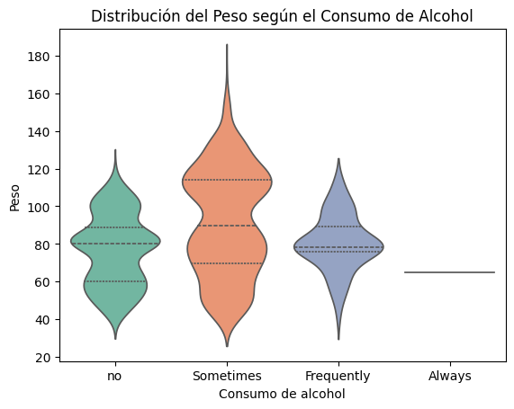

```python
sns.violinplot(x='CALC', y='Weight', hue='CALC', data=df2, palette='Set2', inner='quartile', legend=False)
plt.title("Distribución del Peso según el Consumo de Alcohol")
plt.xlabel("Consumo de alcohol")
plt.ylabel("Peso")
plt.show()
```

## **Paso 4: Limpieza y Acondicionado de Datos**

[ inicio del documento ]

Identificar valores extremos es un paso crucial en el análisis exploratorio de datos, ya que estos pueden ser indicadores de errores de medición, inconsistencias en la recolección de datos o características excepcionales en la población analizada.

En el caso de la variable del peso, los valores extremos podrían representar errores (por ejemplo, pesos registrados erróneamente) o individuos con características únicas que podrían influir significativamente en el análisis.

```python
# Calcular el rango intercuartílico (IQR)
Q1 = df2['Weight'].quantile(0.25)  # Percentil 25
Q3 = df2['Weight'].quantile(0.75)  # Percentil 75
IQR = Q3 - Q1  # Rango intercuartílico

# Definir límites para valores extremos
lower_bound = Q1 - 1.5 * IQR
upper_bound = Q3 + 1.5 * IQR

print("Límite inferior:", lower_bound)
print("Límite superior:", upper_bound)

# Filtrar valores extremos
extreme_values = df2[(df2['Weight'] < lower_bound) | (df2['Weight'] > upper_bound)]
print("Valores extremos en peso:")
print(extreme_values)
```

```
Límite inferior: 2.529999999999987
Límite superior: 170.37
Valores extremos en peso:
    Gender  Age  Height  Weight family_history_with_overweight FAVC  FCVC  \
344   Male   18    1.87   173.0                            yes  yes   3.0

     NCP        CAEC SMOKE  CH2O SCC  FAF  TUE       CALC  \
344  3.0  Frequently    no   2.0  no  2.0  1.0  Sometimes

                    MTRANS        NObeyesdad
344  Public_Transportation  Obesity_Type_III
```

Para entender mejor los valores extremos, vamos a crear un gráfico de caja `boxplot`

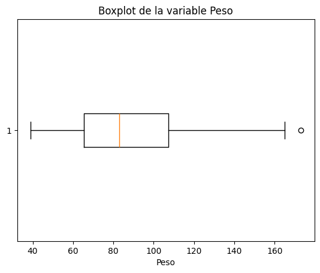

```python
import matplotlib.pyplot as plt

# Crear un boxplot para la variable 'Weight'
plt.boxplot(df2['Weight'], vert=False)
plt.title("Boxplot de la variable Peso")
plt.xlabel("Peso")
plt.show()
```

Tras los datos que hemos obtenido, se realizan las siguientes observaciones:

- El límite superior calculado para los valores aceptables de peso es de 170. 37kg , mientras que el individuo identificado tiene un peso de 173kg, ligeramente por encima del límite. Este caso podría considerarse como un caso extremo en el análisis estadístico, pero observamos que el individuo tiene 18 años, altura de 1.87m con historial familiar con sobre peso y la case de obesidad es de nivel tres (Obesity_Type_III), lo que indica obesidad severa.

Consideramos que este valor extremo es particularmente relevante en el contexto médico, ya que representa un caso de obesidad severa (Tipo III), lo que podría implicar riesgos adicionales de salud, como problemas cardíacos, diabetes u otras enfermedades crónicas. Este valor, podría formar parte de un cluster especifico de pacientes con características similares, ayudando a identificar patrones en la población con obesidad severa, por lo que de momento vamos a mantener este dato en el análisis.

También vamos a comprobar que nuestras variables categoricas no contengan valores inconsistentes, como errores de escritura o duplicados en formato.

```python
# Identificar todas las columnas categóricas en el DataFrame
categorical_columns = df2.select_dtypes(include=['object']).columns

# Asegurar consistencia en todas las variables categóricas
for column in categorical_columns:
    df2[column] = df2[column].str.strip().str.capitalize()
    print(f"Valores únicos en {column}:")
    print(df2[column].unique())
```

```
Valores únicos en Gender:
['Female' 'Male']
Valores únicos en family_history_with_overweight:
['Yes' 'No']
Valores únicos en FAVC:
['No' 'Yes']
Valores únicos en CAEC:
['Sometimes' 'Frequently' 'Always' 'No']
Valores únicos en SMOKE:
['No' 'Yes']
Valores únicos en SCC:
['No' 'Yes']
Valores únicos en CALC:
['No' 'Sometimes' 'Frequently' 'Always']
Valores únicos en MTRANS:
['Public_transportation' 'Walking' 'Automobile' 'Motorbike' 'Bike']
Valores únicos en NObeyesdad:
['Normal_weight' 'Overweight_level_i' 'Overweight_level_ii'
 'Obesity_type_i' 'Insufficient_weight' 'Obesity_type_ii'
 'Obesity_type_iii']
```

Ahora vamos a convertir en valores numéricos las variables categoricas.

Para las variables como `CAEC`, `CALC` y `MTRANS` que tienen más de dos categorías, utilizaremos la funcion `pd.get_dummies()`, esto creará columnas adicionales para cada categoría

```python
# One-Hot Encoding para variables con múltiples categorías
df = pd.get_dummies(df2, columns=['CAEC', 'CALC', 'MTRANS'], drop_first=True)

print("Valores numéricos para variables categóricas múltiples:")
print(df.head())
```

```
Valores numéricos para variables categóricas múltiples:
   Gender  Age  Height  Weight family_history_with_overweight FAVC  FCVC  NCP  \
0  Female   21    1.62    64.0                            Yes   No   2.0  3.0
1  Female   21    1.52    56.0                            Yes   No   3.0  3.0
2    Male   23    1.80    77.0                            Yes   No   2.0  3.0
3    Male   27    1.80    87.0                             No   No   3.0  3.0
4    Male   22    1.78    89.8                             No   No   2.0  1.0

  SMOKE  CH2O  ... CAEC_Frequently  CAEC_No  CAEC_Sometimes CALC_Frequently  \
0    No   2.0  ...           False    False            True           False
1   Yes   3.0  ...           False    False            True           False
2    No   2.0  ...           False    False            True            True
3    No   2.0  ...           False    False            True            True
4    No   2.0  ...           False    False            True           False

   CALC_No  CALC_Sometimes  MTRANS_Bike  MTRANS_Motorbike  \
0     True           False        False             False
1    False            True        False             False
2    False           False        False             False
3    False           False        False             False
4    False            True        False             False

   MTRANS_Public_transportation  MTRANS_Walking
0                          True           False
1                          True           False
2                          True           False
3                         False            True
4                          True           False

[5 rows x 24 columns]
```

El siguiente paso será convertir a variables numéricas todas las variables boolean, es decir, las que contienen valores como True/ False, para que contengan valores 0 y 1. Pero primero tendremos que pasar a variables boolean las que contienen valores Yes/No.

```python
# Comprovamos las variables
boolean_like_cols = []

for col in df.columns:
    unique_vals = df[col].dropna().unique()
    if set(unique_vals).issubset({'Yes', 'No'}):
        boolean_like_cols.append(col)

print("Columnas con valores 'Yes'/'No':", boolean_like_cols)
```

```
Columnas con valores 'Yes'/'No': ['family_history_with_overweight', 'FAVC', 'SMOKE', 'SCC']
```

```python
# convertimos los valores
boolean_map = {'Yes': True, 'No': False}
columns_to_convert = ['family_history_with_overweight', 'FAVC', 'SMOKE', 'SCC']

for col in columns_to_convert:
    df[col] = df[col].astype(str).map(boolean_map)
```

```python
print(df[columns_to_convert].dtypes)
print(df[columns_to_convert].head())
```

```
family_history_with_overweight    bool
FAVC                              bool
SMOKE                             bool
SCC                               bool
dtype: object
   family_history_with_overweight   FAVC  SMOKE    SCC
0                            True  False  False  False
1                            True  False   True   True
2                            True  False  False  False
3                           False  False  False  False
4                           False  False  False  False
```

En el siguiente paso codificaremos la variable categorica Gender a valores numericos donde el valor Male sera 0 y Female 1

```python
# Mapear las categorías de Gender a valores 0 y 1
df['Gender'] = df['Gender'].map({'Male': 0, 'Female': 1})
print(df['Gender'].head())
```

```
0    1
1    1
2    0
3    0
4    0
Name: Gender, dtype: int64
```

```python
# Comprovamos las variables de nuestro conjunto de datos
df.head()
```

|  | Gender | Age | Height | Weight | family_history_with_overweight | FAVC | FCVC | NCP | SMOKE | CH2O | ... | CAEC_Frequently | CAEC_No | CAEC_Sometimes | CALC_Frequently | CALC_No | CALC_Sometimes | MTRANS_Bike | MTRANS_Motorbike | MTRANS_Public_transportation | MTRANS_Walking |
| --- | --- | --- | --- | --- | --- | --- | --- | --- | --- | --- | --- | --- | --- | --- | --- | --- | --- | --- | --- | --- | --- |
| 0 | 1 | 21 | 1.62 | 64.0 | True | False | 2.0 | 3.0 | False | 2.0 | ... | False | False | True | False | True | False | False | False | True | False |
| 1 | 1 | 21 | 1.52 | 56.0 | True | False | 3.0 | 3.0 | True | 3.0 | ... | False | False | True | False | False | True | False | False | True | False |
| 2 | 0 | 23 | 1.80 | 77.0 | True | False | 2.0 | 3.0 | False | 2.0 | ... | False | False | True | True | False | False | False | False | True | False |
| 3 | 0 | 27 | 1.80 | 87.0 | False | False | 3.0 | 3.0 | False | 2.0 | ... | False | False | True | True | False | False | False | False | False | True |
| 4 | 0 | 22 | 1.78 | 89.8 | False | False | 2.0 | 1.0 | False | 2.0 | ... | False | False | True | False | False | True | False | False | True | False |

5 rows × 24 columns

Ahora convertimos las variables boolean en numericas, clasificando false= 0 y true= 1:

```python
# Selecciona todas las columnas de tipo bool
bool_cols = df.select_dtypes(include='bool').columns

# Convierte esas columnas a enteros (True → 1, False → 0)
df[bool_cols] = df[bool_cols].astype(int)

print(df.head())
```

[output not shown]

## **Paso 5: Discretización**

[ inicio del documento ]

Para seguir con nuestro análisis, y tras haber transformado todas las variables categóricas en datos numéricos, vamos a proceder con la discretización de la variable `Age`. Este paso tiene como objetivo segmentar a los individuos en rangos de edad y peso significativos que permitan identificar patrones de comportamiento y correlaciones relacionadas con los niveles de obesidad.

```python
# Definir los intervalos y etiquetas para discretizar Age
bins = [14, 18, 30, 45, 60, 100]  # Límites de los intervalos
labels = ['Adolescente', 'Adulto Joven', 'Adulto Medio', 'Adulto Mayor', 'Anciano'] # Categorías

# Discretizar la variable Age
df['Age_Category'] = pd.cut(df['Age'], bins=bins, labels=labels, include_lowest=True)
print(df[['Age', 'Age_Category']].head())
```

[output not shown]

Una vez discretizada la edad, podemos convertir estas categorías a valores numéricos:

```python
from sklearn.preprocessing import LabelEncoder

df['Age_Category'] = LabelEncoder().fit_transform(df['Age_Category'])
print(df[['Age', 'Age_Category']].head())
```

[output not shown]

Además, esta transformación facilitará la integración de la edad como un atributo categórico en análisis posteriores, como métodos de agrupamiento no supervisados y supervisados, y en la identificación de predictores clave de la obesidad."

## **Paso 6: Análisis PCA**

[ inicio del documento ]

En esta sección, procederemos con el análisis de Componentes Principales (PCA) con el objetivo de reducir la dimensionalidad del conjunto de datos y detectar patrones entre las variables. Este método nos permitirá identificar cuáles son las características más relevantes en el contexto del estudio de la obesidad, optimizando el análisis posterior.

Como paso previo al PCA, es necesario garantizar que todas las variables numéricas tengan la misma escala, ya que este análisis es sensible a las magnitudes y rangos de las variables. Para ello, se aplicará la técnica de normalización `Min-Max Scalin` que transforma los valores para que se encuentren dentro de un rango uniforme, permitiendo un tratamiento equitativo entre las diferentes variables.

```python
# Identificamos las columnas numéricas
numeric_columns = df.select_dtypes(include=['float64', 'int64']).columns
print("Variables numéricas a normalizar:")
print(numeric_columns)
```

```
Variables numéricas a normalizar:
Index(['Gender', 'Age', 'Height', 'Weight', 'family_history_with_overweight',
       'FAVC', 'FCVC', 'NCP', 'SMOKE', 'CH2O', 'SCC', 'FAF', 'TUE',
       'CAEC_Frequently', 'CAEC_No', 'CAEC_Sometimes', 'CALC_Frequently',
       'CALC_No', 'CALC_Sometimes', 'MTRANS_Bike', 'MTRANS_Motorbike',
       'MTRANS_Public_transportation', 'MTRANS_Walking', 'Age_Category'],
      dtype='object')
```

```python
from sklearn.preprocessing import MinMaxScaler

# Crear un objeto MinMaxScaler
scaler = MinMaxScaler()

# Normalizar las columnas numéricas
df[numeric_columns] = scaler.fit_transform(df[numeric_columns])

print("Variables normalizadas:")
print(df.head())
```

```
Variables normalizadas:
   Gender       Age    Height    Weight  family_history_with_overweight  FAVC  \
0     1.0  0.148936  0.320755  0.186567                             1.0   0.0
1     1.0  0.148936  0.132075  0.126866                             1.0   0.0
2     0.0  0.191489  0.660377  0.283582                             1.0   0.0
3     0.0  0.276596  0.660377  0.358209                             0.0   0.0
4     0.0  0.170213  0.622642  0.379104                             0.0   0.0

   FCVC       NCP  SMOKE  CH2O  ...  CAEC_No  CAEC_Sometimes  CALC_Frequently  \
0   0.5  0.666667    0.0   0.5  ...      0.0             1.0              0.0
1   1.0  0.666667    1.0   1.0  ...      0.0             1.0              0.0
2   0.5  0.666667    0.0   0.5  ...      0.0             1.0              1.0
3   1.0  0.666667    0.0   0.5  ...      0.0             1.0              1.0
4   0.5  0.000000    0.0   0.5  ...      0.0             1.0              0.0

  CALC_No  CALC_Sometimes  MTRANS_Bike  MTRANS_Motorbike  \
0     1.0             0.0          0.0               0.0
1     0.0             1.0          0.0               0.0
2     0.0             0.0          0.0               0.0
3     0.0             0.0          0.0               0.0
4     0.0             1.0          0.0               0.0

   MTRANS_Public_transportation  MTRANS_Walking  Age_Category
0                           1.0             0.0          0.25
1                           1.0             0.0          0.25
2                           1.0             0.0          0.25
3                           0.0             1.0          0.25
4                           1.0             0.0          0.25

[5 rows x 25 columns]
```

```python
df.head()
```

[output not shown]

5 rows × 25 columns

Una vez normalizados nuestros datos, hacemos una matriz de correlacion y usaremos un mapa de calor con la libreria seaborn para representar gráficamente las correlaciones entre las variables de interes. Los colores indican la magnitud y dirección de las correlaciones.

```python
selected_columns = ['Gender', 'Height', 'Weight', 'family_history_with_overweight', 'FAF',
                    'FAVC','CH2O', 'CALC_Frequently', 'CALC_Sometimes','CAEC_Sometimes', 'CAEC_Frequently', 'MTRANS_Public_transportation', 'MTRANS_Walking', 'Age_Category']

# Crear un DataFrame con las variables seleccionadas
df_selected = df[selected_columns]
```

```python
import pandas as pd

# Calcular la matriz de correlación
correlation_matrix = df_selected.corr()

# Mostrar la matriz de correlación
print("Matriz de correlación:")
print(correlation_matrix)
```

```
Matriz de correlación:
                                  Gender    Height    Weight  \
Gender                          1.000000 -0.618145 -0.161665
Height                         -0.618145  1.000000  0.462264
Weight                         -0.161665  0.462264  1.000000
family_history_with_overweight -0.102512  0.247245  0.496819
FAF                            -0.189590  0.295354 -0.051355
FAVC                           -0.064934  0.177721  0.272303
CH2O                           -0.107889  0.213469  0.200543
CALC_Frequently                -0.034848  0.046101 -0.041779
CALC_Sometimes                  0.037694  0.106449  0.259599
CAEC_Sometimes                 -0.071790  0.142166  0.411802
CAEC_Frequently                 0.123224 -0.121890 -0.380657
MTRANS_Public_transportation    0.160184 -0.089820  0.059332
MTRANS_Walking                 -0.039317  0.036925 -0.100805
Age_Category                   -0.035935 -0.025875  0.150641

                                family_history_with_overweight       FAF  \
Gender                                               -0.102512 -0.189590
Height                                                0.247245  0.295354
Weight                                                0.496819 -0.051355
family_history_with_overweight                        1.000000 -0.056647
FAF                                                  -0.056647  1.000000
FAVC                                                  0.208036 -0.107936
CH2O                                                  0.147376  0.167181
CALC_Frequently                                      -0.022154  0.054810
CALC_Sometimes                                       -0.024637 -0.136175
CAEC_Sometimes                                        0.340981 -0.048546
CAEC_Frequently                                      -0.269018  0.033386
MTRANS_Public_transportation                         -0.058927 -0.048789
MTRANS_Walking                                       -0.067076  0.108921
Age_Category                                          0.153569 -0.049269

                                    FAVC      CH2O  CALC_Frequently  \
Gender                         -0.064934 -0.107889        -0.034848
Height                          0.177721  0.213469         0.046101
Weight                          0.272303  0.200543        -0.041779
family_history_with_overweight  0.208036  0.147376        -0.022154
FAF                            -0.107936  0.167181         0.054810
FAVC                            1.000000  0.009733        -0.056795
```

[output cut: 41 more lines]

```
                                MTRANS_Walking  Age_Category
Gender                               -0.039317     -0.035935
Height                                0.036925     -0.025875
Weight                               -0.100805      0.150641
family_history_with_overweight       -0.067076      0.153569
FAF                                   0.108921     -0.049269
FAVC                                 -0.179473      0.016845
CH2O                                  0.008317     -0.051993
CALC_Frequently                       0.018819      0.038256
CALC_Sometimes                       -0.050946      0.009445
CAEC_Sometimes                       -0.078208      0.093603
CAEC_Frequently                       0.042381     -0.082165
MTRANS_Public_transportation         -0.284754     -0.505374
MTRANS_Walking                        1.000000     -0.073489
Age_Category                         -0.073489      1.000000
```

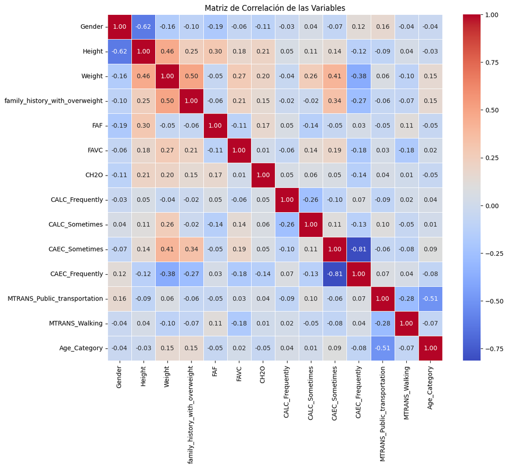

```python
import seaborn as sns
import matplotlib.pyplot as plt

# Configurar el tamaño del gráfico
plt.figure(figsize=(12, 10))

# Crear mapa de calor para la matriz de correlación
sns.heatmap(correlation_matrix, annot=True, cmap='coolwarm', fmt=".2f", linewidths=0.5)

# Añadir título al mapa de calor
plt.title("Matriz de Correlación de las Variables")
plt.show()
```

Esta matriz muestra las correlaciones lineales entre variables numéricas o transformadas numéricamente. Los valores oscilan entre:

- +1: correlación positiva perfecta (ambas variables aumentan juntas),
- 0: sin correlación lineal,
- –1: correlación negativa perfecta (una sube y la otra baja).

**Correlaciones positivas destacadas:**

Podemos observar una correlación positiva significativa entre `Weight` y `Height` , lo cual era esperable dada la relación directa entre estas variables. Esto indica que las personas con mayor altura suelen tener un mayor peso, lo que refuerza la importancia de considerar ambas variables al analizar patrones relacionados con la obesidad.

Además, existe una correlación positiva entre `family_historu_with_overwight` y `CAEC_Sometimes`, lo que sugiere que las personas con antecedentes familiares de sobrepeso tienden a consumir alimentos a deshoras, también tiene correlacion con la variable `FAVC`(Consumo frecuente de alimentos con alto contenido calórico), esta variable también tiene correlacion con el peso. Esto puede reflejar influencias genéticas o comportamientos aprendidos en el entorno familiar.

**Relaciones excluyentes:**

En cuanto a las variables como `CAEC_Sometimes` y `CAEC_Frequently` , observamos una correlación negativa fuerte, lo cual es lógico ya que estas categorías son mutuamente excluyentes. Esto garantiza que las variables fueron correctamente transformadas durante la preparación de los datos.

```python
# Crear un nuevo DataFrame excluyendo la columna "Age"
df_selected_class = df.drop(columns=['Age'])

# Mostrar las primeras filas del nuevo DataFrame
print(df_selected_class.head())
```

```
   Gender    Height    Weight  family_history_with_overweight  FAVC  FCVC  \
0     1.0  0.320755  0.186567                             1.0   0.0   0.5
1     1.0  0.132075  0.126866                             1.0   0.0   1.0
2     0.0  0.660377  0.283582                             1.0   0.0   0.5
3     0.0  0.660377  0.358209                             0.0   0.0   1.0
4     0.0  0.622642  0.379104                             0.0   0.0   0.5

        NCP  SMOKE  CH2O  SCC  ...  CAEC_No  CAEC_Sometimes CALC_Frequently  \
0  0.666667    0.0   0.5  0.0  ...      0.0             1.0             0.0
1  0.666667    1.0   1.0  1.0  ...      0.0             1.0             0.0
2  0.666667    0.0   0.5  0.0  ...      0.0             1.0             1.0
3  0.666667    0.0   0.5  0.0  ...      0.0             1.0             1.0
4  0.000000    0.0   0.5  0.0  ...      0.0             1.0             0.0

   CALC_No  CALC_Sometimes  MTRANS_Bike  MTRANS_Motorbike  \
0      1.0             0.0          0.0               0.0
1      0.0             1.0          0.0               0.0
2      0.0             0.0          0.0               0.0
3      0.0             0.0          0.0               0.0
4      0.0             1.0          0.0               0.0

   MTRANS_Public_transportation  MTRANS_Walking  Age_Category
0                           1.0             0.0          0.25
1                           1.0             0.0          0.25
2                           1.0             0.0          0.25
3                           0.0             1.0          0.25
4                           1.0             0.0          0.25

[5 rows x 24 columns]
```

### **Proceso de PCA**

Tanto el análisis de componentes principales, principal componente analysis (PCA) en inglés, como la descomposición de valores singulares, singular value decomposition (SVD) en inglés, son técnicas que nos permitan trabajar con nuevas características llamadas componentes, que ciertamente son independientes entre sí. En realidad, estas dos técnicas nos permiten representar el juego de datos en un nuevo sistema de coordenadas que denominamos componentes principales. Este sistema está mejor adaptado a la distribución del juego de datos, de forma que recoge mejor su variabilidad.

Aplicamos el análisis de componentes principales a las variables seleccionadas del conjunto de datos.

```python
import pandas as pd
import numpy as np
from sklearn.decomposition import PCA
from sklearn.preprocessing import StandardScaler
import matplotlib.pyplot as plt


# Seleccionamos las variables
selected_variables = ['Weight', 'Height', 'family_history_with_overweight',
                      'FAF', 'CAEC_Frequently', 'CH2O', 'FAVC', 'Age_Category']

# Subconjunto de datos con las variables seleccionadas
data_selected = df[selected_variables]

# Escalamos los datos para asegurarnos
scaler = StandardScaler()
data_scaled = scaler.fit_transform(data_selected)

pca = PCA()
pca_result = pca.fit(data_scaled)

# Desviación estándar de cada componente
std_dev = np.sqrt(pca.explained_variance_)

# Proporción de varianza explicada
prop_var = pca.explained_variance_ratio_

# Proporción acumulada de varianza explicada
cum_var = np.cumsum(prop_var)

# Combinar todo en un DataFrame
summary_df = pd.DataFrame({
    'Standard deviation': std_dev,
    'Proportion of Variance': prop_var,
    'Cumulative Proportion': cum_var
}, index=[f'PC{i+1}' for i in range(len(std_dev))])

# Mostrar el resumen
pd.set_option("display.precision", 5)  # Formato similar al de R
print("Importance of components:")
print(summary_df.T)  # Transpuesta para que quede como en R
```

```
Importance of components:
                            PC1      PC2      PC3      PC4      PC5      PC6  \
Standard deviation      1.51303  1.17096  0.99817  0.94993  0.87181  0.85452
Proportion of Variance  0.28602  0.17131  0.12448  0.11274  0.09496  0.09123
Cumulative Proportion   0.28602  0.45733  0.58182  0.69456  0.78952  0.88076

                            PC7      PC8
Standard deviation      0.76980  0.60152
Proportion of Variance  0.07404  0.04521
Cumulative Proportion   0.95479  1.00000
```

Como se puede observar, hemos obtenido la proporción de varianza aplicada al conjunto de datos de cada atributo. Gracias a esto, podemos ver que el atributo 1, es decir PC1 explica el 28% de los datos y PC2 el 17%, llevando la proporción acumulada a un 45.7%, esto indica que los dos primeros componentes principales ya explican casi la mitad de los datos.

Observamos que seleccionando los 4 componentes principales explicarian el 69.4% de la varianza, esto sugiere que podriamos reducir el conjunto de datos a 4 dimensiones.

```python
# Pesos (cargas) de las variables en los componentes principales
components_df = pd.DataFrame(pca.components_, columns=selected_variables, index=[f'PC{i+1}' for i in range(len(std_dev))])
print("Pesos de las variables en los componentes principales:")
print(components_df)
```

```
Pesos de las variables en los componentes principales:
      Weight   Height  family_history_with_overweight      FAF  \
PC1  0.55237  0.41297                         0.46097  0.04517
PC2 -0.07872  0.40552                        -0.16951  0.66948
PC3  0.01697 -0.05146                         0.10931  0.24677
PC4 -0.03372 -0.39297                         0.03823 -0.26216
PC5  0.12612  0.09824                         0.35344 -0.40000
PC6 -0.21573 -0.17492                        -0.27960  0.06014
PC7 -0.29474 -0.43516                         0.70030  0.42405
PC8  0.73345 -0.52757                        -0.22771  0.27695

     CAEC_Frequently     CH2O     FAVC  Age_Category
PC1         -0.37478  0.25071  0.30052       0.12724
PC2          0.16888  0.40136 -0.24009      -0.32430
PC3          0.01920  0.03208 -0.51217       0.81271
PC4         -0.43474  0.62337 -0.39051      -0.21015
PC5          0.75809  0.30546 -0.14080      -0.04120
PC6          0.14060  0.53707  0.62281       0.38075
PC7          0.05053 -0.05830  0.17086      -0.13556
PC8          0.21126 -0.03580  0.01787      -0.09451
```

De los pesos de las variables en los componentes principales, hemos extraido las sigueintes observacione:

- PC1 y PC2: Representan características físicas y hábitos saludables, que explican gran parte de la variabilidad en los datos. Estos componentes son ideales para reducir la dimensionalidad manteniendo información relevante
- PC3 y PC4: Capturan relaciones entre la edad, alimentación y estilo de vida. Ofrecen un segundo nivel de interpretación centrado en patrones de comportamiento.
- Componentes menores: Los componentes posteriores pueden aportar detalles adicionales que no son dominantes pero complementan el análisis.

Podemos representar en un grafico la proporcion de varianza explicada por cada componente:

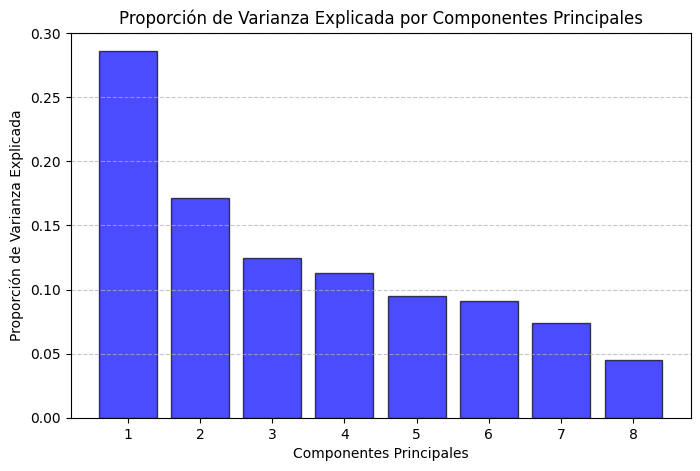

```python
import matplotlib.pyplot as plt

# Crear un histograma de la proporción de varianza explicada
plt.figure(figsize=(8, 5))
plt.bar(range(1, len(prop_var) + 1), prop_var, alpha=0.7, color='blue', edgecolor='black')
plt.title("Proporción de Varianza Explicada por Componentes Principales")
plt.xlabel("Componentes Principales")
plt.ylabel("Proporción de Varianza Explicada")
plt.grid(axis='y', linestyle='--', alpha=0.7)
plt.xticks(range(1, len(prop_var) + 1))
plt.show()
```

En este grafico vemos como la proporción de varianza explicada por los componentes principales, es más elevada en los 3 priemeros componentes.

En el PCA, hemos visto que Weight tiene el peso más alto en el PC1 (0.55237) y Height también tiene un impacto considerable (0.41297). Esto indica que estas variables son fundamentales para explicar la mayor parte de la variabilidad en los datos. A continuacion vamos a representar un scatterplot que refuerza esta importancia al mostrar cómo estas variables interactúan directamente con NObeyesdad.

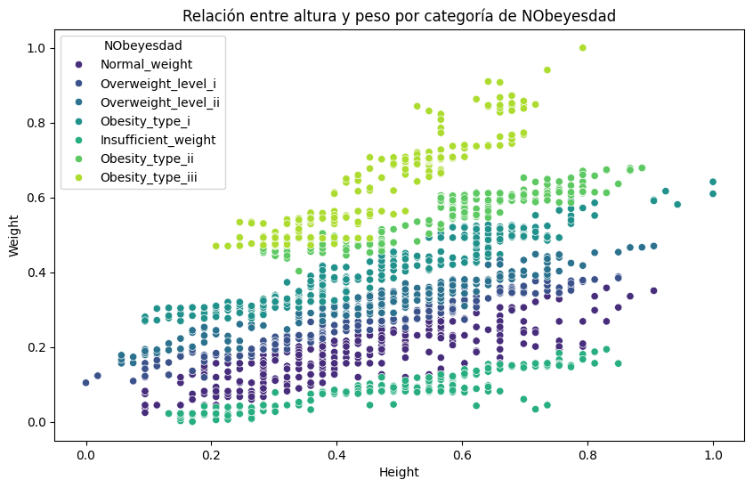

```python
# Scatterplot para observar la relación entre dos variables y NObeyesdad
plt.figure(figsize=(10, 6))
sns.scatterplot(x=df['Height'], y=df['Weight'], hue=df['NObeyesdad'], palette='viridis')
plt.title("Relación entre altura y peso por categoría de NObeyesdad")
plt.xlabel("Height")
plt.ylabel("Weight")
plt.legend(title="NObeyesdad")
plt.show()
```

En el análisis gráfico entre Weight, Height y las categorías de obesidad (NObeyesdad), se observan patrones claros que sugieren diferenciaciones naturales en los datos. Por ejemplo, las categorías de obesidad más graves tienden a ocupar áreas específicas en el espacio definido por el peso y la altura. Si nos fijamos en la clasificacion de la obesidad tipo III, vemos que estas más separada del resto. También se puede observar la relación de la altura y peso como ya nombramos anteriormente, a medida que la altura aumenta, también lo hace el peso.

Estos patrones sugieren que las diferencias observadas en los datos no dependen exclusivamente de las categorías predefinidas (NObeyesdad), sino que existen agrupamientos implícitos que pueden ser explorados mediante técnicas de clustering.

Para continuar con nuestro estudio, podríamos identificar agrupamientos naturales en los datos sin depender de la variable NObeyesdad. Esto permitirá descubrir clasificaciones basadas únicamente en las características inherentes de los datos, como el peso, la altura y otras variables significativas